# Praticing Statistical Analysis & Machine Learning Techniques- Cancellation Risks in Insurance Contracts

# Random-Forest with K-fold Cross-Validation

```r
# Random Forest avec K_fold cross validation
set.seed(123)
mtry<- sqrt(ncol(data_trainRF))
modelRfcv<- train(TOP_RESIL~., data=data_trainRF,method='parRF', trControl=trainControl(method="cv",number=10,allowParallel = TRUE),metric='Accuracy',tuneGrid=expand.grid(.mtry=mtry))# use 'parRF' and not 'rf' as method so that  running faster however it tooks 5 hours!!!
#see the details of the model
modelRfcv
```

```
## Parallel Random Forest
##
## 129257 samples
##     62 predictor
##      3 classes: '0', '1', '2'
##
## No pre-processing
## Resampling: Cross-Validated (10 fold)
## Summary of sample sizes: 116331, 116333, 116331, 116331, 116332, 116332, ...
## Resampling results:
##
##   Accuracy   Kappa
##   0.9419142  0.5209873
##
## Tuning parameter 'mtry' was held constant at a value of 7.937254
##
```

```r
# make predictions
predictionsRfcv<- predict(modelRfcv,data_testRF[,2:63])
confusionMatrix(predictionsRfcv, data_testRF[,1])
```

```
## Confusion Matrix and Statistics
##
##           Reference
## Prediction     0     1     2
##          0 50282   253  2908
##          1     0     0     0
##          2    40    45  1867
##
## Overall Statistics
##
##                Accuracy : 0.9414
##                  95% CI : (0.9394, 0.9433)
##     No Information Rate : 0.9084
##     P-Value [Acc > NIR] : < 2.2e-16
##
##                   Kappa : 0.5139
##  Mcnemar's Test P-Value : < 2.2e-16
##
## Statistics by Class:
##
##                      Class: 0 Class: 1 Class: 2
## Sensitivity            0.9992  0.00000  0.39099
## Specificity            0.3769  1.00000  0.99832
## Pos Pred Value         0.9409      NaN  0.95645
## Neg Pred Value         0.9795  0.99462  0.94559
## Prevalence             0.9084  0.00538  0.08620
## Detection Rate         0.9077  0.00000  0.03370
## Detection Prevalence   0.9648  0.00000  0.03524
## Balanced Accuracy      0.6881  0.50000  0.69466
```

```r
# check Variable Improtance with this model
varImp(modelRfcv)
```

```
## parRF variable importance
##
##   only 20 most important variables shown (out of 278)
##
##                                Overall
## PRESTFM_N                       100.00
## ADH_DUREE                        96.99
## CGAFM_N                          96.52
## CGAFM_N_1                        80.51
## BASEDMC_TYPERESILDefinitive      78.92
## AFF_FM_N2                        67.30
## AFF_FM_N1                        63.87
## AFF_FM_NBSAL                     54.75
## BASEDMC_SOUSCCONCURRENCEOui      52.77
## BASEDMC_RESIL_MOTIFAutre motif   52.64
## CTX_TOPLJ1                       50.13
## CGAFM_N_2                        48.73
## AFF_FM_N3                        48.43
## PRESTFM_N_1                      47.54
## AFF_FM_TAUXSAL                   47.24
## ADH_OFC1                         46.49
## PRESTFM_N_3                      45.56
## AFF_NBSAL                        43.74
## CGAFM_N_3                        40.03
## CTCO_NB_TELSORTANT               37.12
```

```r
varImpPlot(modelRfcv,type2)
```

```
## Error in varImpPlot(modelRfcv, type2): This function only works for objects of class `randomForest'
```

# Naives Bayes algorithms

- Naive Bayes on the train & test sets ( we will use the train set& the test set used by RF model )

```r
modelNB <- NaiveBayes(TOP_RESIL~., data=data_trainRF)

# create a test set and a target set
x_testNB <- data_testRF[,2:63]
y_testNB <- data_testRF[,1]
# make prediction
predictionsNB <- predict(modelNB, x_testNB)
# summarize results
confusionMatrix(predictionsNB$class, y_testNB)#need e1071
```

```
## Confusion Matrix and Statistics
##
##           Reference
## Prediction     0     1     2
##          0 20948    54   147
##          1  5058   123   195
##          2 24316   121  4433
##
## Overall Statistics
##
##                Accuracy : 0.4604
##                  95% CI : (0.4562, 0.4646)
##     No Information Rate : 0.9084
##     P-Value [Acc > NIR] : 1
##
##                   Kappa : 0.1121
##  Mcnemar's Test P-Value : <2e-16
##
## Statistics by Class:
##
##                      Class: 0 Class: 1 Class: 2
## Sensitivity            0.4163  0.41275  0.92838
## Specificity            0.9604  0.90466  0.51725
## Pos Pred Value         0.9905  0.02288  0.15355
## Neg Pred Value         0.1423  0.99650  0.98711
## Prevalence             0.9084  0.00538  0.08620
## Detection Rate         0.3782  0.00222  0.08003
## Detection Prevalence   0.3818  0.09705  0.52117
## Balanced Accuracy      0.6883  0.65871  0.72281
```

```r
prop.table(table(predictionsNB$class, y_testNB))# pauvre précision , surtout beaucoup de FN pour l clasee
```

```
##    y_testNB
##                0            1            2
##   0 0.3781568734 0.0009748172 0.0026536691
##   1 0.0913078798 0.0022204170 0.0035201733
##   2 0.4389565845 0.0021843127 0.0800252730
```

```r
# this model does not give a significant accuracy
```

- Naive Bayes with K-fold Cross-Validation (repeated and no repeated)

```r
# create a data for NB algorithm
datNBcv<- dat1[!myvars1]#
dim(datNBcv)
```

```
## [1] 184652     63
```

```r
split=0.75
trainIndexNB <- createDataPartition(datNBcv$TOP_RESIL, p=split, list=FALSE)
data_trainNB <- datNBcv[ trainIndexNB,]
data_testNB <- datNBcv[-trainIndexNB,]
dim(data_trainNB)
```

```
## [1] 138490     63
```

```r
dim(data_testNB)
```

```
## [1] 46162    63
```

```r
table(data_trainNB$TOP_RESIL)
```

```
##
##      0      1      2
## 125805    747  11938
```

```r
table(data_testNB$TOP_RESIL)
```

```
##
##     0     1     2
## 41935   248  3979
```

```r
# run a NB model with CV  not repeated
set.seed(1234)
modelNBcv = train(data_trainNB[,2:63],data_trainNB[,1],'nb',trControl=trainControl(method='cv',number=10))
predictionsNBcv <- predict(modelNBcv,data_testNB[,2:63])
confusionMatrix(predictionsNBcv, data_testNB[,1])
```

```
## Confusion Matrix and Statistics
##
##           Reference
## Prediction     0     1     2
##          0 38798   241  2266
##          1     4     0     2
##          2  3133     7  1711
##
## Overall Statistics
##
##                Accuracy : 0.8775
##                  95% CI : (0.8745, 0.8805)
##     No Information Rate : 0.9084
##     P-Value [Acc > NIR] : 1
##
##                   Kappa : 0.3124
##  Mcnemar's Test P-Value : <2e-16
##
## Statistics by Class:
##
##                      Class: 0 Class: 1 Class: 2
## Sensitivity            0.9252 0.000000  0.43001
## Specificity            0.4069 0.999869  0.92556
## Pos Pred Value         0.9393 0.000000  0.35271
## Neg Pred Value         0.3541 0.994627  0.94510
## Prevalence             0.9084 0.005372  0.08620
## Detection Rate         0.8405 0.000000  0.03707
## Detection Prevalence   0.8948 0.000130  0.10509
## Balanced Accuracy      0.6661 0.499935  0.67778
```

```r
# NB with CV repeated
set.seed(2453)
modelNBcvr = train(data_trainNB[,2:63],data_trainNB[,1],'nb',trControl=trainControl(method='repeatedcv',number=10,repeats = 5))
predictionsNBcvr <- predict(modelNBcvr,data_testNB[,2:63])
confusionMatrix(predictionsNBcvr, data_testNB[,1])
```

```
## Confusion Matrix and Statistics
##
##           Reference
## Prediction     0     1     2
##          0 38798   241  2266
##          1     4     0     2
##          2  3133     7  1711
##
## Overall Statistics
##
##                Accuracy : 0.8775
##                  95% CI : (0.8745, 0.8805)
##     No Information Rate : 0.9084
##     P-Value [Acc > NIR] : 1
##
##                   Kappa : 0.3124
##  Mcnemar's Test P-Value : <2e-16
##
## Statistics by Class:
##
##                      Class: 0 Class: 1 Class: 2
## Sensitivity            0.9252 0.000000  0.43001
## Specificity            0.4069 0.999869  0.92556
## Pos Pred Value         0.9393 0.000000  0.35271
## Neg Pred Value         0.3541 0.994627  0.94510
## Prevalence             0.9084 0.005372  0.08620
## Detection Rate         0.8405 0.000000  0.03707
## Detection Prevalence   0.8948 0.000130  0.10509
## Balanced Accuracy      0.6661 0.499935  0.67778
```

# Feature Engineering 2nd attempt ( data preparation for implementing other algorithmes)

```r
# VAR importance:
library(pROC)
filterVarImp(varnum2[,2:30],varnum2$TOP_RESIL,nonpara = FALSE)
```

```
##                           X0        X1        X2
## ENT_ANCIENNETE     0.5904520 0.5804630 0.5904520
## CTAD_NB_FM         0.5164093 0.5164093 0.4802410
## CTCO_NB_FM         0.4965397 0.4965397 0.4555395
## CTAD_NB_HORSFM     0.4742834 0.4742834 0.4654384
## CTCO_NB_HORSFM     0.4485942 0.4669205 0.4669205
## CTAD_NB_INA        0.5201688 0.5201688 0.4869539
## CTAD_NB_INAFM      0.5186497 0.5186497 0.5017367
## CTCO_NB_VISITE     0.5128074 0.5128074 0.3758288
## CTCO_NB_SIM        0.5024040 0.5024040 0.4751867
## CTAD_NB_TELENTRANT 0.5604002 0.5604002 0.3530553
## CTAD_NB_TELSORTANT 0.5416729 0.5416729 0.4608876
## CTCO_NB_TELENTRANT 0.5734777 0.5734777 0.4547978
## CTCO_NB_TELSORTANT 0.4466209 0.4466209 0.3421677
## PRESTFM_N          0.5051842 0.5051842 0.2427972
## PRESTFM_N_1        0.5332085 0.5332085 0.3642746
## PRESTFM_N_2        0.5653019 0.5653019 0.4575438
## PRESTFM_N_3        0.5763144 0.5763144 0.5241348
## CGAFM_N            0.4499158 0.4499158 0.2889115
## CGAFM_N_1          0.4752325 0.4752325 0.3398661
## CGAFM_N_2          0.5305371 0.5305371 0.3913048
## CGAFM_N_3          0.5590301 0.5590301 0.4870886
## AGE_MOYEN          0.5284549 0.5284549 0.5037545
## ADH_DUREE          0.6693948 0.6595900 0.6693948
## AFF_NBSAL          0.5436572 0.5436572 0.3299721
## AFF_FM_NBSAL       0.4335708 0.4335708 0.3739750
## AFF_FM_TAUXSAL     0.3659862 0.3924956 0.3924956
## AFF_FM_N1          0.5337078 0.5337078 0.4735202
## AFF_FM_N2          0.5565517 0.5565517 0.5122165
## AFF_FM_N3          0.5443158 0.5443158 0.5236693
```

Create dummy variabes- One hot encoding

```r
# create dummy variables/ count frequencies

datnew<-dat
summarizeColumns(datnew)
```

```
##                           name    type na         mean         disp
## 1                      MUNAENT integer  0 4.087092e+07 2.807438e+07
## 2                    TOP_RESIL  factor  0           NA 9.158850e-02
## 3                  ENT_TYPGRPE  factor  0           NA 5.109070e-02
## 4                       ENT_DR  factor  0           NA 8.470149e-01
## 5                     ENT_DEPT  factor  0           NA 9.706042e-01
## 6               ENT_ANCIENNETE numeric  0 5.038036e+03 4.175652e+03
## 7                     ENT_NACE  factor  0           NA 8.233488e-01
## 8                   ENT_APENAF  factor  0           NA 8.224660e-01
## 9                   ENT_CATJUR  factor  0           NA 5.536360e-01
## 10                  ENT_TOPTEL  factor  0           NA 8.194333e-02
## 11              ENT_TOPTELPORT  factor  0           NA 4.271928e-01
## 12                 ENT_TOPMAIL  factor  0           NA 2.013680e-01
## 13                   INT_DTABO  factor  0           NA 8.985660e-01
## 14                    ENT_CHEF  factor  0           NA 3.723382e-01
```

[output cut: 129 more lines]

```r
# one-hot-encoding categorical features
one_hot_encodeVar= c('ENT_TYPGRPE', 'ENT_DR', 'ADHENT_RET','ADHENT_GAT', 'ADHENT_PRV', 'ADHENT_PVS','ADHENT_GDIA',
                  'ADHENT_RCJ','ADHENT_PPAB','ADHENT_EPS','ADH_TYPCT','ADH_GAMMEERP','ADH_TARIF','BASEDMC_TYPERESIL',
                  'BASEDMC_SOUSCCONCURRENCE')
dummies <- dummyVars(~ ENT_TYPGRPE+ENT_DR + ADHENT_RET +ADHENT_GAT+ADHENT_PRV+ADHENT_PVS+ADHENT_GDIA+
                  ADHENT_RCJ+ADHENT_PPAB+ADHENT_EPS+ADH_TYPCT+ADH_GAMMEERP+ADH_TARIF+BASEDMC_TYPERESIL+BASEDMC_SOUSCCONCURRENCE,
                  data = datnew)
datnew1 <- as.data.frame(predict(dummies, newdata = datnew))

dim(datnew1)
```

```
## [1] 184652     70
```

```r
#colnames(datnew1)
datnewcombined <- cbind(datnew[,-c(which(colnames(datnew) %in% one_hot_encodeVar))],datnew1)
```

Convert new columns to factor

```r
# convert new columns to factor
to.factors<- function ( df,variables){
  for (variable in variables){
    df[[variable]]<- as.factor(df[[variable]])
  }
  return(df)
}

categoric.vars<- c(colnames(datnew1))
datnewcombined<- to.factors(datnewcombined,categoric.vars)
```

Remove the variables having more than 99% null values

```r
myvars2<- names(datnewcombined)%in% c('ADH_GAMMEERP.O - N' ,'ADH_GAMMEERP.N - O')
datnewcombined<-datnewcombined[!myvars2]
dim(datnewcombined)
```

```
## [1] 184652    124
```

Remove the categorical variables having too many levels

```r
myvars3<- names(datnewcombined)%in% c('INT_DTABO' ,'ENT_CATJUR','ENT_APENAF','ENT_NACE','ENT_DEPT')
datnewcombined<-datnewcombined[!myvars3]
datnewcombined$AGE_MOYEN[is.na(datnewcombined$AGE_MOYEN)]<- median(datnewcombined$AGE_MOYEN,na.rm = TRUE)
```

Splitting classes in the new data set

```r
splitclass2<- split(names(datnewcombined), sapply(datnewcombined, function(x){class(x)}))
#splitclass2
varnum3<-datnewcombined[splitclass2$numeric]
# correlation within numeric variables
cor1<-cor(varnum3)
head(cor1,3)
```

```
##                ENT_ANCIENNETE  CTAD_NB_FM  CTCO_NB_FM CTAD_NB_HORSFM
## ENT_ANCIENNETE     1.00000000 -0.01837687 -0.03362992     0.02400576
## CTAD_NB_FM        -0.01837687  1.00000000  0.54576982     0.44940537
## CTCO_NB_FM        -0.03362992  0.54576982  1.00000000     0.39334800
##                CTCO_NB_HORSFM CTAD_NB_INA CTAD_NB_INAFM CTCO_NB_VISITE
## ENT_ANCIENNETE     -0.0250986  0.04270025    0.00481226    -0.03534467
## CTAD_NB_FM          0.4301057  0.08353448    0.12172913     0.12452489
## CTCO_NB_FM          0.4994327  0.02686128    0.03723211     0.18187934
##                CTCO_NB_SIM CTAD_NB_TELENTRANT CTAD_NB_TELSORTANT
## ENT_ANCIENNETE  -0.0422348         0.03633654       -0.008627555
## CTAD_NB_FM       0.4324031         0.20483028        0.108657085
## CTCO_NB_FM       0.7189753         0.09396540        0.082859131
##                CTCO_NB_TELENTRANT CTCO_NB_TELSORTANT    PRESTFM_N
## ENT_ANCIENNETE        -0.07494401        -0.04569379  0.099197845
## CTAD_NB_FM             0.14644388         0.14276960 -0.009233709
## CTCO_NB_FM             0.17926587         0.26689698 -0.018036726
##                PRESTFM_N_1 PRESTFM_N_2 PRESTFM_N_3      CGAFM_N
## ENT_ANCIENNETE  0.10311014  0.10875755  0.12349045  0.078320661
## CTAD_NB_FM     -0.01226299 -0.01257597 -0.01409518 -0.007778472
## CTCO_NB_FM     -0.02049565 -0.02054158 -0.02280763 -0.014074778
##                   CGAFM_N_1    CGAFM_N_2   CGAFM_N_3   AGE_MOYEN
## ENT_ANCIENNETE  0.083835693  0.092157587  0.10014416  0.14773475
## CTAD_NB_FM     -0.009279845 -0.009722412 -0.01073154 -0.07638667
## CTCO_NB_FM     -0.015689577 -0.016526611 -0.01782421 -0.08867748
##                  ADH_DUREE    AFF_NBSAL AFF_FM_NBSAL AFF_FM_TAUXSAL
## ENT_ANCIENNETE  0.69764851  0.109189159  0.101913283    -0.01978661
## CTAD_NB_FM     -0.07889151 -0.003741307 -0.004936117     0.05163638
## CTCO_NB_FM     -0.11722109 -0.016223922 -0.016508611     0.04301387
##                  AFF_FM_N1   AFF_FM_N2   AFF_FM_N3
## ENT_ANCIENNETE  0.11145820  0.11980613  0.15351072
## CTAD_NB_FM     -0.01243403 -0.01355277 -0.01538673
## CTCO_NB_FM     -0.02376194 -0.02399204 -0.02838338
```

```r
#create a data containing numeric variables and the target
varnum4<-subset(datnewcombined, select = c('TOP_RESIL',splitclass2$numeric))
varnum4$AGE_MOYEN[is.na(varnum4$AGE_MOYEN)]<- median(varnum4$AGE_MOYEN,na.rm = TRUE)
```

Reduce data dimensions: based on Var importance obtained by the Random Forest model

```r
myvars4<-names(datnewcombined)%in% c('TOP_RESIL','PRESTFM_N','PRESTFM_N_1','PRESTFM_N_2','PRESTFM_N_3','CGAFM_N',
                                    'CGAFM_N_1', 'CGAFM_N_2','CGAFM_N_3','ADH_DUREE','AFF_FM_N1',
                                    'AFF_FM_N2','AFF_FM_N3','ENT_ANCIENNETE','AGE_MOYEN','AFF_NBSAL',
                                    'AFF_FM_NBSAL','CTCO_NB_TELSORTANT','CTAD_NB_TELENTRANT','ADH_OFC',
                                    'ADHENT_PPAB.0','ADHENT_PPAB.1','ADHENT_PPAB.2','CTX_TOPLJ',
                                    'ADH_TARIF.FOR - FOR','ADH_TARIF.FOR - Non',"ADH_TARIF.FOR - SAL" ,
                                    "ADH_TARIF.Non - FOR","ADH_TARIF.Non - Non","ADH_TARIF.Non - SAL",                                            "ADH_TARIF.SAL - FOR","ADH_TARIF.SAL - Non" ,"ADH_TARIF.SAL - SAL",
                                    "TIERS_TOPCPT","ADHENT_PPAB.0","ADHENT_PPAB.1","ADHENT_PPAB.2")
datnewcombined1<- datnewcombined[myvars4]
```

Splitting the train set and the test set

```r
# split data train and data set
split=0.75
trainIndex3 <- createDataPartition(datnewcombined1$TOP_RESIL, p=split, list=FALSE)
data_trainnew <- datnewcombined1[ trainIndex3,]
data_testnew <- datnewcombined1[-trainIndex3,]
dim(data_trainnew)
```

```
## [1] 138490     34
```

```r
dim(data_testnew)
```

```
## [1] 46162    34
```

```r
table(data_trainnew$TOP_RESIL)
```

```
##
##      0      1      2
## 125805    747  11938
```

# Statistical & Machine Learning

Since the outcome have more than 2 classes ( 0,1,2 ), I have choosen 2 parametric algorithmes: Multinomial Logistic and Linear Discriminant Analysis. This choice is also based on the objective of our project: building predictive models providing interesting informations on the relation between the target and the variables of the models which are also our business metrics.

For discovering and getting better a look on the profile of each client group ( 0,1 or 2), I will use Tree Decision algorithm that may capture non linear relations better than two last ones.

Let’s do with the Multinomial Logistic model

# Multinomial Logistic model

```r
data_trainnew$TOP_RESIL2 <- relevel(data_trainnew$TOP_RESIL, ref = "0")
data_trainnew1<-data_trainnew[-1]
set.seed(234)
modelLog <- multinom(TOP_RESIL2 ~., data = data_trainnew1)# fit the model
summary(modelLog)
```

```
## Call:
## multinom(formula = TOP_RESIL2 ~ ., data = data_trainnew1)
##
## Coefficients:
##   (Intercept) ENT_ANCIENNETE TIERS_TOPCPT1 CTAD_NB_TELENTRANT
## 1    2.790013   3.380190e-05     -2.835362         0.02906075
## 2    4.794328   6.753135e-05     -2.359679         0.03428461
##   CTCO_NB_TELSORTANT CTX_TOPLJ1     PRESTFM_N   PRESTFM_N_1  PRESTFM_N_2
## 1        -0.08441471  0.9167254 -0.0002394117 -7.474631e-06 7.998409e-06
## 2        -0.15631957  1.3412639 -0.0014839667 -1.935151e-05 1.100493e-05
##    PRESTFM_N_3       CGAFM_N     CGAFM_N_1     CGAFM_N_2    CGAFM_N_3
## 1 5.603904e-06  2.329108e-05 -9.197973e-05 -1.029192e-05 1.863599e-05
## 2 1.075546e-05 -8.392733e-03 -3.993321e-05 -2.292295e-05 1.601671e-05
##      AGE_MOYEN     ADH_DUREE   ADH_OFC1  AFF_NBSAL AFF_FM_NBSAL AFF_FM_N1
## 1 -0.008327189 -2.456020e-05 -0.1253306 0.05292037   -0.1536012 0.1786577
## 2  0.013238420 -1.752474e-05 -3.6936485 0.06762239   -0.1084920 0.2889261
##     AFF_FM_N2   AFF_FM_N3 ADHENT_PPAB.01 ADHENT_PPAB.11 ADHENT_PPAB.21
## 1 0.028756695 0.005829272      -5.610494       13.79602      -5.395518
## 2 0.007586391 0.031691583      -5.807775       15.91474      -5.312638
##   `ADH_TARIF.FOR - FOR`1 `ADH_TARIF.FOR - Non`1 `ADH_TARIF.FOR - SAL`1
## 1               1.656976            -0.05825378              1.8030566
## 2              -0.223853             0.78531331              0.9934368
##   `ADH_TARIF.Non - FOR`1 `ADH_TARIF.Non - Non`1 `ADH_TARIF.Non - SAL`1
## 1             -1.0829231              1.6608071              -1.484371
## 2              0.7040929              0.9615405               1.453971
##   `ADH_TARIF.SAL - FOR`1 `ADH_TARIF.SAL - Non`1 `ADH_TARIF.SAL - SAL`1
## 1             2.49218764             -3.5964612               1.398994
## 2             0.02198414              0.2618966              -0.164054
##
## Std. Errors:
##    (Intercept) ENT_ANCIENNETE TIERS_TOPCPT1 CTAD_NB_TELENTRANT
## 1 3.352211e-05   1.112908e-05  3.135239e-05       0.0004181691
## 2 5.170837e-05   4.544036e-06  4.241840e-05       0.0053053026
##   CTCO_NB_TELSORTANT   CTX_TOPLJ1    PRESTFM_N  PRESTFM_N_1  PRESTFM_N_2
## 1       8.720607e-05 1.877826e-05 2.402967e-05 1.413651e-05 1.012522e-05
## 2       7.353452e-04 8.547478e-05 4.252687e-05 1.099003e-05 8.263316e-06
##    PRESTFM_N_3      CGAFM_N    CGAFM_N_1    CGAFM_N_2    CGAFM_N_3
## 1 1.035157e-05 2.144211e-05 8.369898e-06 9.369186e-06 8.371048e-06
## 2 6.606201e-06 2.081778e-04 1.040835e-05 8.941511e-06 6.499791e-06
##      AGE_MOYEN    ADH_DUREE     ADH_OFC1   AFF_NBSAL AFF_FM_NBSAL
## 1 0.0014308545 1.737428e-05 2.024766e-05 0.003449585  0.002248771
## 2 0.0005441051 5.727338e-06 1.731743e-05 0.003580017  0.003435759
##     AFF_FM_N1   AFF_FM_N2   AFF_FM_N3 ADHENT_PPAB.01 ADHENT_PPAB.11
## 1 0.002254718 0.003447441 0.002281412   3.334817e-05   1.082303e-07
## 2 0.003935014 0.002223891 0.003693225   4.913228e-05   1.082304e-07
##   ADHENT_PPAB.21 `ADH_TARIF.FOR - FOR`1 `ADH_TARIF.FOR - Non`1
## 1   3.359057e-07           2.545897e-05           6.159491e-06
## 2   5.667329e-06           3.133781e-05           5.318635e-05
##   `ADH_TARIF.FOR - SAL`1 `ADH_TARIF.Non - FOR`1 `ADH_TARIF.Non - Non`1
## 1           2.631495e-05           1.748567e-06           1.017474e-05
## 2           9.307949e-05           8.470884e-05           4.399491e-05
##   `ADH_TARIF.Non - SAL`1 `ADH_TARIF.SAL - FOR`1 `ADH_TARIF.SAL - Non`1
## 1           3.932627e-06           7.585224e-07           2.510286e-08
## 2           1.106933e-04           1.171494e-06           2.429391e-06
##   `ADH_TARIF.SAL - SAL`1
## 1           7.933683e-06
## 2           1.918649e-05
##
## Residual Deviance: 51420.96
## AIC: 51548.96
```

```r
# extract the coefficients from the model and compute their exponentiate values
exp(coef(modelLog))
```

```
##   (Intercept) ENT_ANCIENNETE TIERS_TOPCPT1 CTAD_NB_TELENTRANT
## 1    16.28122       1.000034    0.05869729           1.029487
## 2   120.82317       1.000068    0.09445050           1.034879
##   CTCO_NB_TELSORTANT CTX_TOPLJ1 PRESTFM_N PRESTFM_N_1 PRESTFM_N_2
## 1          0.9190500   2.501087 0.9997606   0.9999925    1.000008
## 2          0.8552858   3.823874 0.9985171   0.9999806    1.000011
##   PRESTFM_N_3   CGAFM_N CGAFM_N_1 CGAFM_N_2 CGAFM_N_3 AGE_MOYEN ADH_DUREE
## 1    1.000006 1.0000233 0.9999080 0.9999897  1.000019 0.9917074 0.9999754
## 2    1.000011 0.9916424 0.9999601 0.9999771  1.000016 1.0133264 0.9999825
##     ADH_OFC1 AFF_NBSAL AFF_FM_NBSAL AFF_FM_N1 AFF_FM_N2 AFF_FM_N3
## 1 0.88220517  1.054346    0.8576140  1.195611  1.029174  1.005846
## 2 0.02488106  1.069961    0.8971861  1.334993  1.007615  1.032199
##   ADHENT_PPAB.01 ADHENT_PPAB.11 ADHENT_PPAB.21 `ADH_TARIF.FOR - FOR`1
## 1    0.003659262       980702.5     0.00453687              5.2434331
## 2    0.003004106      8159887.6     0.00492891              0.7994326
##   `ADH_TARIF.FOR - Non`1 `ADH_TARIF.FOR - SAL`1 `ADH_TARIF.Non - FOR`1
## 1              0.9434105               6.068167              0.3386043
## 2              2.1930940               2.700500              2.0220117
##   `ADH_TARIF.Non - Non`1 `ADH_TARIF.Non - SAL`1 `ADH_TARIF.SAL - FOR`1
## 1               5.263558              0.2266449              12.087691
## 2               2.615723              4.2800760               1.022228
##   `ADH_TARIF.SAL - Non`1 `ADH_TARIF.SAL - SAL`1
## 1             0.02742059              4.0511206
## 2             1.29939218              0.8486962
```

```r
# for interpreting the weight( probability) that each variable can make so that the target move from one to another.
# caculate the probabilities for each obs. in the training set
head(prob <- fitted(modelLog))
```

```
##           0            1            2
## 1 0.9989731 0.0010268651 3.454365e-14
## 2 0.0546884 0.0005047126 9.448069e-01
## 3 0.7038259 0.0004401545 2.957340e-01
## 6 0.9703906 0.0296086458 7.653017e-07
## 7 0.8523985 0.0007315946 1.468699e-01
## 8 0.9779036 0.0007180152 2.137834e-02
```

```r
head(data_trainnew$TOP_RESIL)
```

```
## [1] 0 2 0 0 0 0
## Levels: 0 1 2
```

```r
# var importance
varimptLog<-varImp(modelLog)
varimptLog$variables<-row.names(varimptLog)
varimptLog<-varimptLog[order(-varimptLog$Overall),]
varimptLog
```

```
##                             Overall              variables
## ADHENT_PPAB.11         2.971077e+01         ADHENT_PPAB.11
## ADHENT_PPAB.01         1.141827e+01         ADHENT_PPAB.01
## ADHENT_PPAB.21         1.070816e+01         ADHENT_PPAB.21
## TIERS_TOPCPT1          5.195041e+00          TIERS_TOPCPT1
## `ADH_TARIF.SAL - Non`1 3.858358e+00 `ADH_TARIF.SAL - Non`1
## ADH_OFC1               3.818979e+00               ADH_OFC1
## `ADH_TARIF.Non - SAL`1 2.938342e+00 `ADH_TARIF.Non - SAL`1
## `ADH_TARIF.FOR - SAL`1 2.796493e+00 `ADH_TARIF.FOR - SAL`1
## `ADH_TARIF.Non - Non`1 2.622348e+00 `ADH_TARIF.Non - Non`1
## `ADH_TARIF.SAL - FOR`1 2.514172e+00 `ADH_TARIF.SAL - FOR`1
## CTX_TOPLJ1             2.257989e+00             CTX_TOPLJ1
## `ADH_TARIF.FOR - FOR`1 1.880829e+00 `ADH_TARIF.FOR - FOR`1
## `ADH_TARIF.Non - FOR`1 1.787016e+00 `ADH_TARIF.Non - FOR`1
## `ADH_TARIF.SAL - SAL`1 1.563047e+00 `ADH_TARIF.SAL - SAL`1
## `ADH_TARIF.FOR - Non`1 8.435671e-01 `ADH_TARIF.FOR - Non`1
## AFF_FM_N1              4.675838e-01              AFF_FM_N1
## AFF_FM_NBSAL           2.620932e-01           AFF_FM_NBSAL
## CTCO_NB_TELSORTANT     2.407343e-01     CTCO_NB_TELSORTANT
## AFF_NBSAL              1.205428e-01              AFF_NBSAL
## CTAD_NB_TELENTRANT     6.334536e-02     CTAD_NB_TELENTRANT
## AFF_FM_N3              3.752085e-02              AFF_FM_N3
## AFF_FM_N2              3.634309e-02              AFF_FM_N2
## AGE_MOYEN              2.156561e-02              AGE_MOYEN
## CGAFM_N                8.416024e-03                CGAFM_N
## PRESTFM_N              1.723378e-03              PRESTFM_N
## CGAFM_N_1              1.319129e-04              CGAFM_N_1
## ENT_ANCIENNETE         1.013332e-04         ENT_ANCIENNETE
## ADH_DUREE              4.208494e-05              ADH_DUREE
## CGAFM_N_3              3.465270e-05              CGAFM_N_3
## CGAFM_N_2              3.321487e-05              CGAFM_N_2
## PRESTFM_N_1            2.682614e-05            PRESTFM_N_1
## PRESTFM_N_2            1.900334e-05            PRESTFM_N_2
## PRESTFM_N_3            1.635937e-05            PRESTFM_N_3
```

```r
# Prediction/ Test Set
data_testnew1<- data_testnew[-1]
predictionLogmulti<-predict(modelLog, newdata = data_testnew1,type="class")
# add "probs" to see probabilities as one of the project's objectives: prediction with probabilities.
predictionLogproba<-predict(modelLog, newdata = data_testnew1,type="probs")
head(predictionLogmulti)
```

```
## [1] 0 0 0 0 0 0
## Levels: 0 1 2
```

```r
# Accuracy
postResample(data_testnew[1],predictionLogmulti)
```

```
##  Accuracy     Kappa
## 0.9313938 0.4368321
```

```r
#Accuracy     Kappa
#0.9293142 0.4204888
# Confusion matrix & Misssiclassification error
table(predictionLogmulti,data_testnew$TOP_RESIL)
```

```
##
## predictionLogmulti     0     1     2
##                  0 41634   210  2621
##                  1     6     6     3
##                  2   295    32  1355
```

```r
prop.table(table(predictionLogmulti,data_testnew$TOP_RESIL))
```

```
##
## predictionLogmulti            0            1            2
##                  0 9.019107e-01 4.549196e-03 5.677830e-02
##                  1 1.299770e-04 1.299770e-04 6.498852e-05
##                  2 6.390538e-03 6.932109e-04 2.935315e-02
```

```r
mean(as.character(predictionLogmulti) != as.character(data_testnew$TOP_RESIL))#.07
```

```
## [1] 0.06860621
```

# Tree decision

```r
# remove the last column used in the logistic model.
data_trainnew<- data_trainnew[-35]
#  fit tree model
modelTree <- rpart(TOP_RESIL~., data= data_trainnew,method = 'class',control=rpart.control(minsplit=100, , minbuckket= 10,maxdeepth=15,cp=0.001))
printcp(modelTree) # display the results
```

```
##
## Classification tree:
## rpart(formula = TOP_RESIL ~ ., data = data_trainnew, method = "class",
##     control = rpart.control(minsplit = 100, , minbuckket = 10,
##         maxdeepth = 15, cp = 0.001))
##
## Variables actually used in tree construction:
##  [1] ADH_DUREE           ADH_OFC             ADH_TARIF.Non - SAL
##  [4] AFF_FM_N1           AFF_FM_N2           AFF_FM_N3
##  [7] AFF_FM_NBSAL        AFF_NBSAL           CGAFM_N
## [10] CGAFM_N_1           CGAFM_N_2           CGAFM_N_3
## [13] CTX_TOPLJ           ENT_ANCIENNETE      PRESTFM_N
## [16] PRESTFM_N_1         PRESTFM_N_2         PRESTFM_N_3
## [19] TIERS_TOPCPT
##
## Root node error: 12685/138490 = 0.091595
##
## n= 138490
##
##           CP nsplit rel error  xerror      xstd
## 1  0.0192090      0   1.00000 1.00000 0.0084624
## 2  0.0093023      9   0.68916 0.69003 0.0071386
## 3  0.0087899     11   0.67056 0.67994 0.0070897
## 4  0.0047037     13   0.65298 0.66054 0.0069944
## 5  0.0042176     16   0.63886 0.64296 0.0069067
## 6  0.0033898     20   0.62199 0.62491 0.0068150
## 7  0.0028380     23   0.61182 0.61482 0.0067631
## 8  0.0026803     24   0.60899 0.61151 0.0067459
## 9  0.0024438     26   0.60363 0.60962 0.0067361
## 10 0.0023256     28   0.59874 0.60552 0.0067147
## 11 0.0022862     30   0.59409 0.60181 0.0066953
## 12 0.0020497     31   0.59180 0.60126 0.0066925
## 13 0.0019971     35   0.58360 0.59850 0.0066780
## 14 0.0017737     38   0.57761 0.59188 0.0066431
## 15 0.0016949     44   0.56697 0.58471 0.0066050
## 16 0.0015767     47   0.56145 0.57935 0.0065763
## 17 0.0015372     48   0.55987 0.56981 0.0065250
## 18 0.0014716     58   0.54024 0.56902 0.0065207
## 19 0.0014190     61   0.53583 0.56137 0.0064791
## 20 0.0011037     62   0.53441 0.55294 0.0064329
## 21 0.0010642     65   0.53110 0.54899 0.0064111
## 22 0.0010511     69   0.52684 0.54821 0.0064068
## 23 0.0010000     72   0.52369 0.54702 0.0064002
```

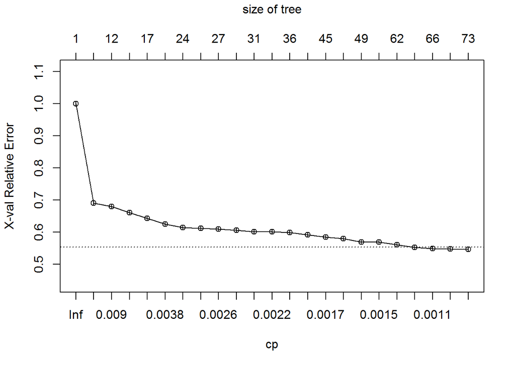

```r
plotcp(modelTree) # visualize cross-validation results
```

```r
#summary(modelTree) # detailed summary of splits# don't run it in Rmarkdown
```

Plot the tree

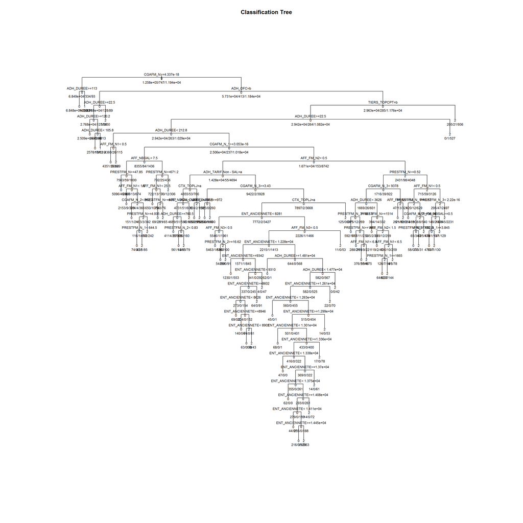

```r
plot(modelTree, uniform=TRUE,
    main="Classification Tree ", margin=0.1)
text(modelTree, use.n=TRUE, all=TRUE, cex=.7)
```

Create and save an image

```r
png("tree.png", res=80, height=2000, width=5000)
plot(modelTree, uniform=TRUE,main="Classification Tree ", margin=0.1)
text(modelTree, use.n=TRUE, all=TRUE, cex=.8)
dev.off()
```

Make a tree prediction

```r
# make prediction
predictree<- predict(modelTree, newdata=data_testnew1,type = 'class')
head(predictree)
```

```
##  4  5  9 13 17 19
##  0  0  0  0  0  0
## Levels: 0 1 2
```

```r
table(predictree,data_testnew$TOP_RESIL)
```

```
##
## predictree     0     1     2
##          0 41498   162  1681
##          1    10    41     2
##          2   427    45  2296
```

```r
prop.table(table(predictree,data_testnew$TOP_RESIL))
```

```
##
## predictree            0            1            2
##          0 8.989645e-01 3.509380e-03 3.641523e-02
##          1 2.166284e-04 8.881764e-04 4.332568e-05
##          2 9.250032e-03 9.748278e-04 4.973788e-02
```

```r
#summary(modelTree) # don't run this one
postResample(data_testnew[1],predictree)
```

```
##  Accuracy     Kappa
## 0.9495906 0.6447766
```

# Linear Discriminant Analysis

Note: this algorithm is adapted only to models with numeric independent variables

```r
#LDA: will work with numeric values only

# center +scale the data before
varnum4[-1]<- scale(varnum4[-1],center = TRUE,scale = TRUE)
# fit the model
modellda <- lda(TOP_RESIL ~ .,
           data=varnum4) # no prior fixed
#see the model
modellda
```

```
## Call:
## lda(TOP_RESIL ~ ., data = varnum4)
##
## Prior probabilities of groups:
##           0           1           2
## 0.908411498 0.005388515 0.086199987
##
## Group means:
##   ENT_ANCIENNETE   CTAD_NB_FM  CTCO_NB_FM CTAD_NB_HORSFM CTCO_NB_HORSFM
## 0    -0.02786086  0.009076469  0.01928259     0.02258131      0.0307834
## 1     0.08575677  0.132068657  0.04957464    -0.09099130     -0.1824447
## 2     0.28824855 -0.103907475 -0.20630700    -0.23228327     -0.3130034
##    CTAD_NB_INA CTAD_NB_INAFM CTCO_NB_VISITE CTCO_NB_SIM CTAD_NB_TELENTRANT
## 0  0.004194589   -0.00447399     0.03251803  0.01424652         0.02701251
## 1  0.177316789    0.28921730     0.12428765  0.10760650         0.25183809
## 2 -0.055288717    0.02906929    -0.35045805 -0.15686248        -0.30041194
##   CTAD_NB_TELSORTANT CTCO_NB_TELENTRANT CTCO_NB_TELSORTANT   PRESTFM_N
## 0         0.01467515         0.01500815         0.05029287  0.01166787
## 1         0.23652958         0.38926741        -0.10005627  0.05813207
## 2        -0.16943879        -0.18249598        -0.52375256 -0.12659480
##    PRESTFM_N_1  PRESTFM_N_2  PRESTFM_N_3      CGAFM_N    CGAFM_N_1
## 0  0.006706921  0.001801154 -0.004200199  0.008999273  0.006383299
## 1  0.105362812  0.151711081  0.234808113  0.005745215  0.045947148
## 2 -0.077266751 -0.028465047  0.029585178 -0.095197249 -0.070142114
##      CGAFM_N_2    CGAFM_N_3   AGE_MOYEN   ADH_DUREE    AFF_NBSAL
## 0  0.003100922 -0.001366508 -0.00335335 -0.04715035 -0.001124033
## 1  0.081631774  0.140960069  0.09905200 -0.01655706  0.132333556
## 2 -0.037781762  0.005589165  0.02914709  0.49792511  0.003573128
##   AFF_FM_NBSAL AFF_FM_TAUXSAL    AFF_FM_N1    AFF_FM_N2    AFF_FM_N3
## 0  0.005090538     0.08102542 -0.002389647 -0.004224037 -0.006605422
## 1  0.063272409    -0.42666694  0.162825181  0.235439508  0.301100345
## 2 -0.057601493    -0.82720805  0.015004605  0.029796926  0.050788382
##
## Coefficients of linear discriminants:
##                             LD1           LD2
## ENT_ANCIENNETE     -0.051098165 -0.1857691533
## CTAD_NB_FM          0.114723835 -0.0965019131
## CTCO_NB_FM         -0.001757083  0.0005037794
## CTAD_NB_HORSFM     -0.109422030  0.0695683823
## CTCO_NB_HORSFM     -0.133286182  0.1836448683
```

[output cut: 13 more lines]

```
## CGAFM_N_1          -1.058828752 -1.7413854219
## CGAFM_N_2           0.522643473  1.8615321964
## CGAFM_N_3           0.329704823  0.0809134171
## AGE_MOYEN          -0.064369393 -0.1150829847
## ADH_DUREE           0.416543464  0.4400767544
## AFF_NBSAL           0.420161416 -0.3199455279
## AFF_FM_NBSAL       -0.829910488  2.2231686625
## AFF_FM_TAUXSAL     -0.689534127  0.0794402565
## AFF_FM_N1           1.221216436 -0.7498029815
## AFF_FM_N2          -0.131769584 -1.1717372702
## AFF_FM_N3          -0.058948283 -0.5388329396
##
## Proportion of trace:
##    LD1    LD2
## 0.9696 0.0304
```

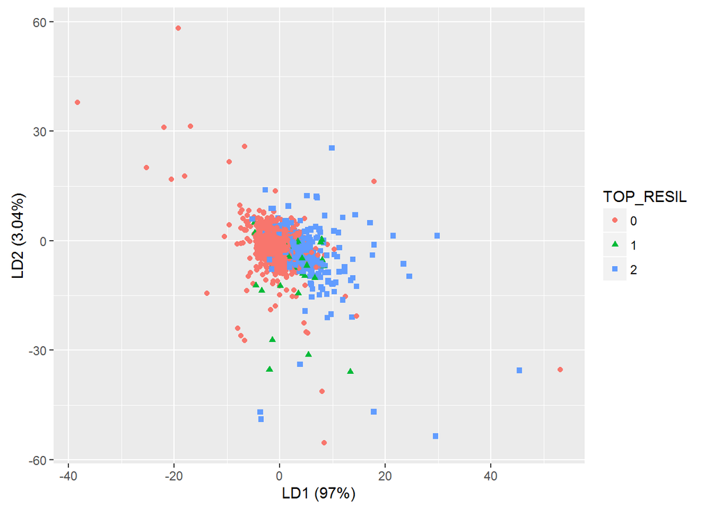

```r
prop.lda = modellda$svd^2/sum(modellda$svd^2)
prediclda <- predict(object = modellda,
                newdata = varnum4)

dataset = data.frame(TOP_RESIL = varnum4[,"TOP_RESIL"],
                     lda = prediclda$x)

plotLda <- ggplot(dataset) + geom_point(aes(lda.LD1, lda.LD2, colour = TOP_RESIL, shape = TOP_RESIL), size = 1.5) +
  labs(x = paste("LD1 (", percent(prop.lda[1]), ")", sep=""),
       y = paste("LD2 (", percent(prop.lda[2]), ")", sep=""))
plotLda
```

```r
#Prediction with LDA

# split train and test set
split=0.75
trainIndex4 <- createDataPartition(varnum4$TOP_RESIL, p=split, list=FALSE)
varnum4_train <- varnum4[ trainIndex4,]
varnum4_test <- varnum4[-trainIndex4,]
dim(varnum4_train)
```

```
## [1] 138490     30
```

```r
dim(varnum4_test)
```

```
## [1] 46162    30
```

```r
# fit the model
modelLda1 <- lda(TOP_RESIL ~ .,
         varnum4_train)
modelLda1
```

```
## Call:
## lda(TOP_RESIL ~ ., data = varnum4_train)
##
## Prior probabilities of groups:
##           0           1           2
## 0.908404939 0.005393891 0.086201170
##
## Group means:
##   ENT_ANCIENNETE   CTAD_NB_FM  CTCO_NB_FM CTAD_NB_HORSFM CTCO_NB_HORSFM
## 0    -0.02739571  0.007265149  0.01903892     0.02222991     0.03051365
## 1     0.11289901  0.131701572  0.04475418    -0.07551173    -0.17238892
## 2     0.28512517 -0.105222229 -0.20689129    -0.23289465    -0.31469384
##    CTAD_NB_INA CTAD_NB_INAFM CTCO_NB_VISITE CTCO_NB_SIM CTAD_NB_TELENTRANT
## 0  0.003509389  -0.004342117     0.03315211  0.01434794         0.02550625
## 1  0.142390400   0.170343989     0.13587996  0.08570666         0.25207176
## 2 -0.054504546   0.036825073    -0.34628672 -0.15702034        -0.30133287
##   CTAD_NB_TELSORTANT CTCO_NB_TELENTRANT CTCO_NB_TELSORTANT   PRESTFM_N
## 0         0.01275142         0.01311126         0.04992274  0.01398725
## 1         0.21435647         0.37343331        -0.10644492  0.06129928
## 2        -0.16391335        -0.18452072        -0.52224139 -0.12653548
##    PRESTFM_N_1  PRESTFM_N_2  PRESTFM_N_3     CGAFM_N    CGAFM_N_1
## 0  0.008848182  0.004052807 -0.001963713  0.01194718  0.008610307
## 1  0.115060810  0.160942539  0.234871651  0.01343897  0.049059020
## 2 -0.076979516 -0.027217015  0.032675153 -0.09510775 -0.069287682
##      CGAFM_N_2    CGAFM_N_3    AGE_MOYEN    ADH_DUREE   AFF_NBSAL
## 0  0.005126958 0.0005354617 -0.003836962 -0.046257959 0.001163362
## 1  0.083123706 0.1434081639  0.108362102 -0.001885081 0.132291189
## 2 -0.035728363 0.0085177334  0.033160270  0.503211237 0.010307744
##   AFF_FM_NBSAL AFF_FM_TAUXSAL    AFF_FM_N1   AFF_FM_N2    AFF_FM_N3
## 0  0.007366821     0.08010166 0.0002450978 -0.00160122 -0.004117853
## 1  0.056918533    -0.44553677 0.1729973324  0.23466754  0.289515620
## 2 -0.052658261    -0.83175354 0.0173789351  0.03026519  0.049805838
##
## Coefficients of linear discriminants:
##                             LD1         LD2
## ENT_ANCIENNETE     -0.060359834 -0.24482089
## CTAD_NB_FM          0.119859251 -0.11672682
## CTCO_NB_FM          0.002458790 -0.01324498
## CTAD_NB_HORSFM     -0.100749617  0.05265472
## CTCO_NB_HORSFM     -0.160764642  0.19478073
```

[output cut: 13 more lines]

```
## CGAFM_N_1          -1.074243786 -1.76295481
## CGAFM_N_2           0.557556222  2.28980683
## CGAFM_N_3           0.280085359 -0.25725770
## AGE_MOYEN          -0.060656764 -0.11765094
## ADH_DUREE           0.431888775  0.47829310
## AFF_NBSAL           0.440840752 -0.45046370
## AFF_FM_NBSAL       -0.909591276  2.97902079
## AFF_FM_TAUXSAL     -0.689131962  0.07277836
## AFF_FM_N1           1.207333972 -1.31057393
## AFF_FM_N2          -0.151224581 -1.19985377
## AFF_FM_N3          -0.076661547 -0.45288592
##
## Proportion of trace:
##    LD1    LD2
## 0.9686 0.0314
```

```r
predictionLda = predict(object = modelLda1, # predictions
               newdata = varnum4_test[,2:30])
table(varnum4_test$TOP_RESIL,predictionLda$class)# not high accuracy
```

```
##
##         0     1     2
##   0 41650    17   268
##   1   236     3     9
##   2  3701    29   249
```

```r
# accuracy for each class
diag(prop.table(table(varnum4_test$TOP_RESIL,predictionLda$class), 1))# not good for classes 1,2
```

```
##          0          1          2
## 0.99320377 0.01209677 0.06257854
```

```r
sum(diag(prop.table(table(varnum4_test$TOP_RESIL,predictionLda$class))))
```

```
## [1] 0.9077163
```

```r
# with cross validation
modelLdacv<-lda(TOP_RESIL ~ .,
         varnum4, CV=TRUE)
#modelLdacv # don't run it in Rmarkdown
table(varnum4$TOP_RESIL,modelLdacv$class)
```

```
##
##          0      1      2
##   0 166627    131    982
##   1    935     14     46
##   2  14790     83   1044
```

```r
diag(prop.table(table(varnum4$TOP_RESIL,modelLdacv$class),1))# not good accuracy for class 1 and 2
```

```
##          0          1          2
## 0.99336473 0.01407035 0.06559025
```

# End Note

This R project is a contributive part of an real Data Project within our organisation. This projet is today ongoing. I have just got started with some data manipulation tasks and machine learning attemps. I have tried some algorithms but I keep exploring other ways to achieve more improvement in accuracy with significant and useful statitical outputs for our business.